Firstly, I will try to get the prey selection coefficients from something easy I am going to try anchovy first.

```r
library(dplyr)
```

```r
library(ggplot2)
library(tidyr)
#reading in the data
load("C:/Users/lucab/Downloads/stomach_dataset.Rdata")

anchovy <- stom_df%>%filter(pred_species=="Engraulis encrasicolus")
#okay there arent very many datarows, so I will use another dataset as well

anc <- read.csv("C:/Users/lucab/Downloads/AnchovyAndSardine.csv")
anc <- anc%>%filter(Species=="anchovy")

#I will combine the two datasets, but i need to get the same format
anchovy <- anchovy%>%select(prey_weight_g, pred_weight_g, nprey_perpred, pred_species,)%>%
rename(wprey=prey_weight_g, wpredator=pred_weight_g, Nprey=nprey_perpred, Species=pred_species)%>%
  mutate(wprey=wprey/Nprey)

anchovy <- rbind(anchovy, anc)

#here is the final dataset to play with,
#lets add ppmr columns
anchovy <- anchovy%>%mutate(ppmr=(wpredator/wprey))
```

Now we have the dataset, first we should check that ppmr doesnt change across predator weights

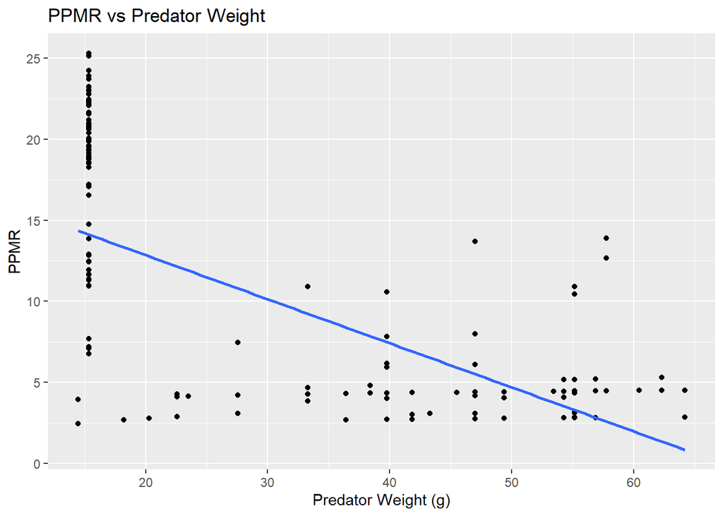

```r
#plotting the ppmr against predator weight

ggplot(anchovy, aes(x=wpredator, y=log(ppmr)))+
  geom_point()+
  geom_smooth(method="lm", se=FALSE)+
  labs(title="PPMR vs Predator Weight", x="Predator Weight (g)", y="PPMR")
```

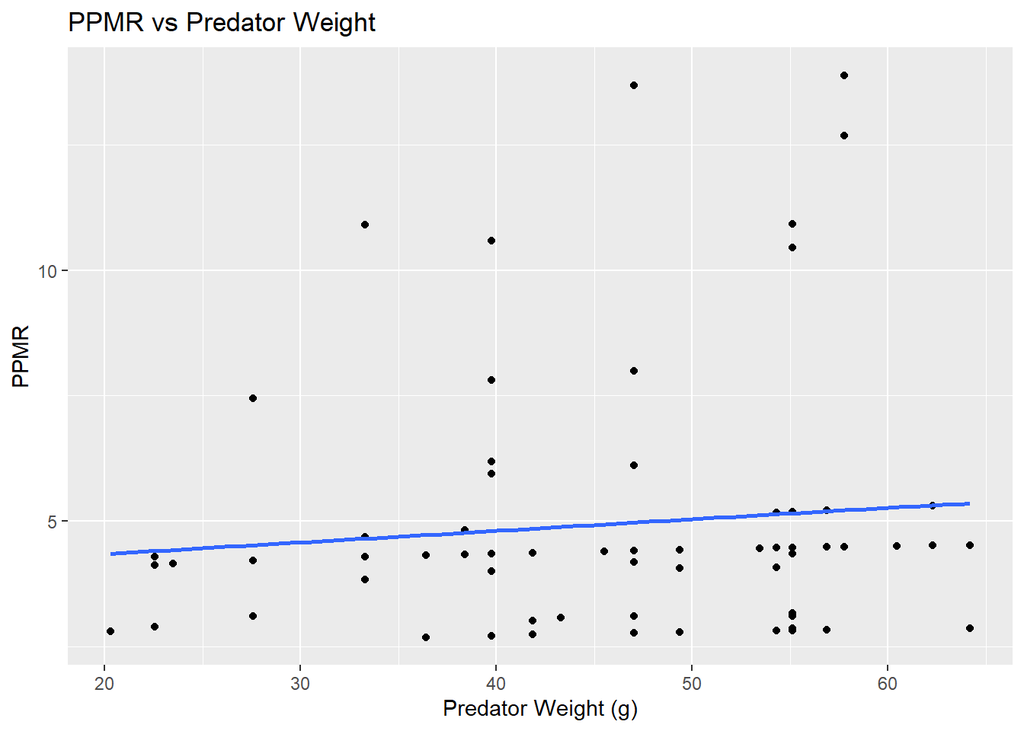

```r
#the lowest sizes of anchovy apparently eat prey that is e^-10, which is very small,
#so i will filter this out

#going to pplot only from 20g onwards

ggplot(anchovy%>%filter(wpredator>20), aes(x=wpredator, y=log(ppmr)))+
  geom_point()+
  geom_smooth(method="gam", se=FALSE)+
  labs(title="PPMR vs Predator Weight", x="Predator Weight (g)", y="PPMR")
```

```r
#this looks a lot better now (i dont know when to use lm or gam, but gam looks better)
#therefore, we can say that ppmr stays the same across predator weights, so we can aggregate predator weights now.
```

It is interesting that we do not have to account for the biomass of the prey to get an equal ppmr across predator weights, maybe because anchovy already eats very small prey, and there isnt a great size variation.

Next step is to plot this all as a density distribution

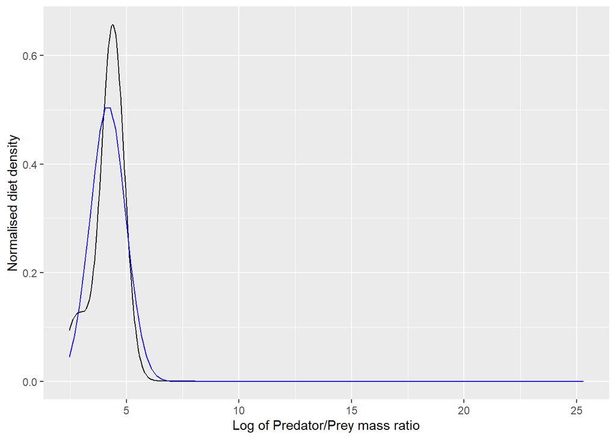

```r
#defining the digestion coefficient
dig <- 2/3

weighted.sd <- function(x, w) { sqrt(sum(w * (x - weighted.mean(x, w))^2)) }

weight <- anchovy$Nprey * (anchovy$wprey/anchovy$wpredator)^dig
weight <- weight / sum(weight)

est_mean <- weighted.mean(log(anchovy$ppmr), weight)
est_sd <- weighted.sd(log(anchovy$ppmr), weight)

ggplot(anchovy) +
  geom_density(aes(log(ppmr), weight = Nprey*wprey^dig), bw = 0.5) +
  stat_function(fun = dnorm, args = list(mean = est_mean, sd = est_sd), colour = "blue") +
  xlab("Log of Predator/Prey mass ratio") + ylab("Normalised diet density")
```

ok, the distribution for it seems to fit. it needs a slightly lower variance however. I will now check it for the number distribution

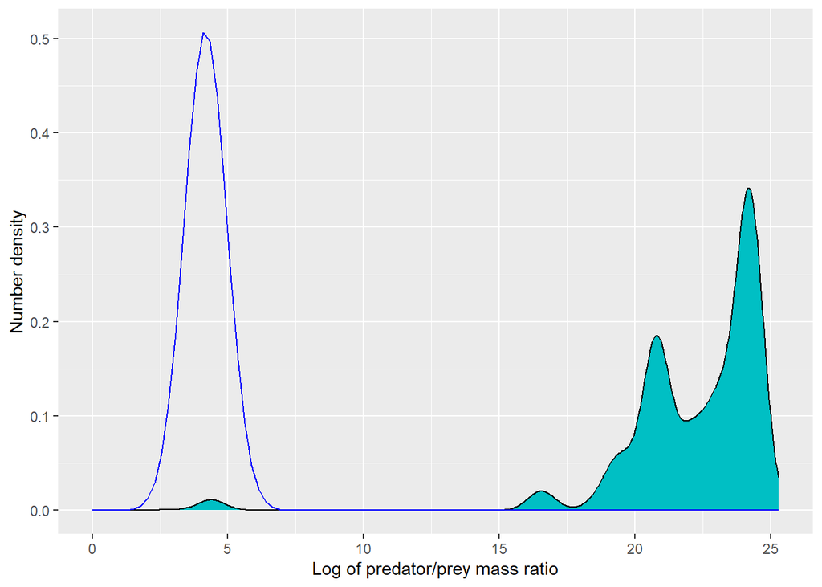

```r
stomach <- anchovy

grid <- seq(0, max(log(stomach$ppmr)), length = 100)

weighted.sd <- function(x, w) { sqrt(sum(w * (x - weighted.mean(x, w))^2)) }

weight <- anchovy$Nprey * (anchovy$wprey/anchovy$wpredator)^dig
weight <- weight / sum(weight)

n_prey <- anchovy$Nprey
weight_numbers = n_prey / sum(n_prey)

est_mean <- weighted.mean(log(stomach$ppmr), weight)
est_sd <- weighted.sd(log(stomach$ppmr), weight)

shifted_normaldens <- data.frame(
        log_ppmr = grid,
        density = dnorm(grid, est_mean, est_sd)
        )


ggplot(stomach) +
    geom_density(aes(log(ppmr), weight = weight_numbers),
                 fill = "#00BFC4", bw = 0.5) +
    xlab("Log of predator/prey mass ratio")  +
    ylab("Number density") +
    geom_line(aes(log_ppmr, density), data = shifted_normaldens,
                  colour = "blue")
```

Okay, so I have plotted this including the anchovy data from the anchovy and sardines file and it does not look right, without including this data, it works. I think this may be to do with different units of measurement between - so I will try to sort this out

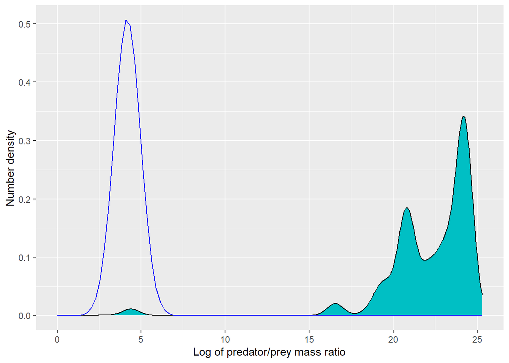

```r
#I will assume that the stomach data is g, and the anchoy and sardines file is in kg

#i have to change this, then read in all the data again and see
anc <- anc%>%mutate(wprey=wprey*1000, wpredator=wpredator*1000)

anchovy <- stom_df%>%filter(pred_species=="Engraulis encrasicolus")

anchovy <- anchovy%>%select(prey_weight_g, pred_weight_g, nprey_perpred, pred_species,)%>%
rename(wprey=prey_weight_g, wpredator=pred_weight_g, Nprey=nprey_perpred, Species=pred_species)%>%
  mutate(wprey=wprey/Nprey)

anchovy <- rbind(anchovy, anc)
anchovy <- anchovy%>%mutate(ppmr=(wpredator/wprey))

#now to plot again

stomach <- anchovy

grid <- seq(0, max(log(stomach$ppmr)), length = 100)

weighted.sd <- function(x, w) { sqrt(sum(w * (x - weighted.mean(x, w))^2)) }

weight <- anchovy$Nprey * (anchovy$wprey/anchovy$wpredator)^dig
weight <- weight / sum(weight)

n_prey <- anchovy$Nprey
weight_numbers = n_prey / sum(n_prey)

est_mean <- weighted.mean(log(stomach$ppmr), weight)
est_sd <- weighted.sd(log(stomach$ppmr), weight)

shifted_normaldens <- data.frame(
        log_ppmr = grid,
        density = dnorm(grid, est_mean, est_sd)
        )


ggplot(stomach) +
    geom_density(aes(log(ppmr), weight = weight_numbers),
                 fill = "#00BFC4", bw = 0.5) +
    xlab("Log of predator/prey mass ratio")  +
    ylab("Number density") +
    geom_line(aes(log_ppmr, density), data = shifted_normaldens,
                  colour = "blue")
```

No, it is the same problem, potentially, they have different sampling methods and in one they are able to sample smaller species. What if I try to plot only the anchovy and sardine data?

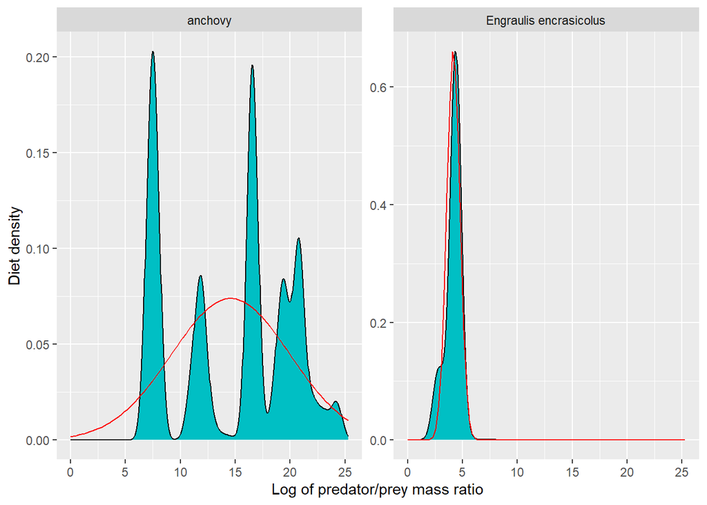

```r
#I am going to plot both, but as separate plots

#need to match the column names to this data.

stomach <- anchovy

colnames(stomach) <- c("w_prey", "w_pred", "n_prey", "pred_species", "log_ppmr")

stomach <- stomach%>%mutate(log_ppmr=log(w_pred/w_prey))

grid <- seq(0, max(stomach$log_ppmr), length = 100)
normaldens <- plyr::ddply(stomach, "pred_species", function(stomach) {
    weight <- stomach$n_prey * (stomach$w_prey / stomach$w_pred)^dig
    weight <- weight / sum(weight)

    est_mean <- weighted.mean(stomach$log_ppmr, weight)
    est_sd <- weighted.sd(stomach$log_ppmr, weight)
    data.frame(
        log_ppmr = grid,
        density = dnorm(grid, est_mean, est_sd)
        )
})

stomach <- stomach |>
    mutate(weight_diet = (n_prey * (w_prey / w_pred)^dig) /
               sum(n_prey * (w_prey / w_pred)^dig))

ggplot(stomach) +
    geom_density(aes(log_ppmr, weight = weight_diet),
                 fill = "#00BFC4", bw = 0.5) +
    facet_wrap(~pred_species, scales = "free_y", ncol = 4) +
    xlab("Log of predator/prey mass ratio")  +
    ylab("Diet density")+
    geom_line(aes(log_ppmr, density), data = normaldens,
                  colour = "red")
```

and now doing the same for the number density

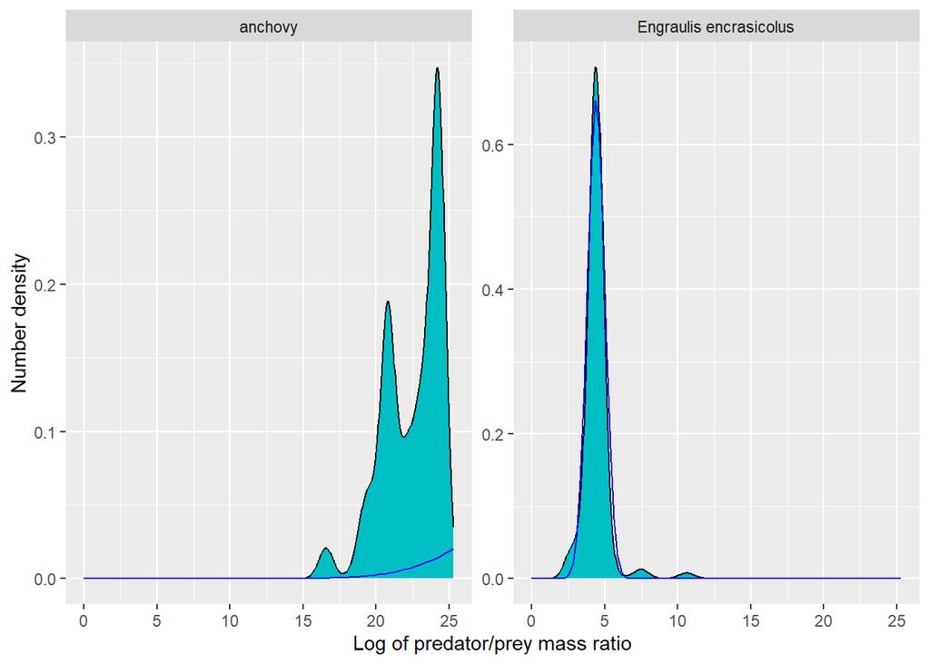

```r
shifted_normaldens <- plyr::ddply(stomach, "pred_species", function(stomach) {
    weight <- stomach$n_prey * (stomach$w_prey / stomach$w_pred)^dig
    weight <- weight / sum(weight)

    est_mean <- weighted.mean(stomach$log_ppmr, weight)
    est_sd <- weighted.sd(stomach$log_ppmr, weight)
    data.frame(
        log_ppmr = grid,
        density = dnorm(grid, est_mean+dig*est_sd^2, est_sd)
        )
})

ggplot(stomach) +
    geom_density(aes(log_ppmr, weight = weight_numbers),
                 fill = "#00BFC4", bw = 0.5) +
    facet_wrap(~pred_species, scales = "free_y", ncol = 4) +
    xlab("Log of predator/prey mass ratio")  +
    ylab("Number density") +
    geom_line(aes(log_ppmr, density), data = shifted_normaldens,
                  colour = "blue")
```

It works very well for the stom_df dataset, but not at all for the anchovy dataset. Not sure why. I think the problem is that Nprey from the anchovy dataset is the probability of the prey item to be in a stomach, whereas this code assumes that Nprey is the number of prey found for those sizes of pred and prey. - thinking about it this shouldnt matter, as it is both a weight of number of observations. - something else must be up with this data.

So I am not sure how to convert this to what we want (will have to redo code to weight it in that fashion)

For now I am just going to use the stomach dataset, and this next section I will run a mixed effects linear model to see the variation not due to region/year

```r
#setting up the model

anchovy <- stom_df%>%filter(pred_species=="Engraulis encrasicolus")%>%
  mutate(wprey=prey_weight_g/nprey_perpred)

#model <- lmer(data=anchovy, wprey~(1|ices_rectangle))

#ok to this model states that 99% percent of the wprey is not due to the region or year
#therefore it must all be due to the predator selection
```

[output not shown]

I think we need more data, as currently there isn’t too much, and if we can figure out how to use the anchovies and sardines datafile, we can include that too, but currently it completely different.